# VersuchMobileUsers

1 Data Mining Versuch Mobile User Analysis and Gender-Age-Group Prediction

2 Einführung

2.1 Kurzbeschreibung:

2.2 Lernziele:

2.3 Aufgaben zur Vorbereitung

3 Durchführung

3.1 Datenzugriff

3.2 Deskriptive Statistik

3.2.1 Verteilung der User über die Gender-Age-Gruppen

3.2.2 Verteilung der User über die Smartphone-Marken

3.3 Spatio-Temporale Analyse des Verhaltens einzelner User

4 Feature Extraction

5 Gender-Age-Group Prediction

# Data Mining Versuch Mobile User Analysis and Gender-Age-Group Prediction

- Autor: Prof. Dr. Johannes Maucher
- Datum: 04.10.2016
- Download des Jupyter Notebooks (.ipynb) Klick auf *Ziel speichern unter*. Im Verzeichnis, in dem das Notebook abgelegt wurde, Konsole öffnen und dort *jupyter notebook* eingeben.

Übersicht Ipython Notebooks im Data Mining Praktikum

# Einführung

## Kurzbeschreibung:

In diesem Versuch werden die im Rahmen eines Kaggle-Contest [von *TalkingData* bereitgestellten Daten](https://www.kaggle.com/c/talkingdata-mobile-user-demographics/data) analysiert. Die Daten enthalten für eine große Menge chinesischer User, Angaben zur Marke und Modell des Smartphones und zu den installierten und aktiven Apps. Ziel ist es aus den zur Verfügung stehenden Trainingsdaten ein Modell zu erlernen, das die Klassifikation der User in die jeweilige Gender-Age-Gruppe erlaubt. Für die Lösung dieser Aufgabe müssen sämtliche Schritte der Data Mining Prozesskette implementiert werden:

1. Datenbeschaffung und Zugriff
2. Datenauswahl: Welche der vorhandenen Daten sind für die gegebene Aufgabe tatsächlich relevant
3. Datenbereinigung: Wie wird mit fehlenden und fehlerhaften Daten umgegangen?
4. Datentransformation: Wie können aus den vorhandenen Daten informative Mermale gewonnen werden?
5. Modellbildung: Unüberwachtes oder überwachtes erlernen eines Modells; Clustering-, Klassifikations- oder Regressionsmodell.
6. Evaluation, Visualisierung und Interpretation der Daten/Ergebnisse

## Lernziele:

In diesem Versuch sollen Kenntnisse in folgenden Themen vermittelt werden:

- Zugriff auf Daten in .csv Files
- Zugriff auf Daten in SQLite Files
- Statistische Analyse und Visualisierung von Daten
- Implementierung der oben genannten Data Mining Prozessschritte, insbesondere:
  - Feature-Engineering: Berechnung von für die gegebene Aufgabe relevanter Daten aus Rohdaten
  - Clustering (unüberwachtes Lernen)
  - Klassifikation/Prädiktion (überwachtes Lernen) mit verschiedenen Machine Learning Verfahren
  - Evaluation von Klassifikationsverfahren

## Aufgaben zur Vorbereitung

1. Laden Sie die Daten entweder vom Skripteserver oder direkt von [Kaggle](https://www.kaggle.com/c/talkingdata-mobile-user-demographics/data) herunter und versuchen Sie die Daten anhand dieser [Beschreibung](https://www.kaggle.com/c/talkingdata-mobile-user-demographics/data) zu verstehen.
2. In diesem Versuch soll die Gender-Age-Group von Smartphone-Usern vorhergesagt werden. Überlegen Sie sich welche der vorhandenen Daten für diese Vorhersage relevant sein könnten.
3. Für die Vorhersage kann ein beliebiger Klassifikationsalgorithmus aus dem Bereich des überwachten Lernens eingesetzt werden. Das Prinzip des überwachten Lernens und das entsprechende Testen des gelernten Modells ist in der unten aufgeführten Abbildung dargestellt. Machen Sie sich mit diesem Prinzip vertraut.
4. Für das überwachte Lernen sind gelabelte Daten (Soll-Ausgabe) notwendig. In diesem Versuch ist die Ausgabe die Gender-Age-Group der User. Im File *gender_age_train.csv* ist für 74645 User (devices) die zugehörigen Gender-Age-Group angegeben. Die Menge aller gelabelten Daten muss für die Modellvalidierung in disjunkte Trainings- und Testpartitionen unterteilt werden. In diesem Versuch kommt sowohl eine einfache Partitionierung in Trainings- und Testdaten als auch eine Kreuzvalidierung zum Einsatz ([KI-Vorlesung](https://www.mi.hdm-stuttgart.de/mib/studium/intern/skripteserver/skripte/Einfuehrung_Kuenstliche_Intelligenz/WS1516/06_PartLernen1.pdf)). Machen Sie sich mit dem Prinzip der Kreuzvalidierung (Abbildung unten) vertraut.
5. Den meisten Machine Learning-Algorithmen können kategoriale Parameter nicht direkt übergeben werden. Diese Parameter werden typisch *One-Hot* encodiert. Machen Sie sich mit diesem Prinzip vertraut.
6. In diesem Versuch soll ein Multilayer-Perzeptron (MLP) als Klassifikator eingesetzt werden. Machen Sie sich mit dem MLP vertraut. [KI-Vorlesung](https://www.mi.hdm-stuttgart.de/mib/studium/intern/skripteserver/skripte/Einfuehrung_Kuenstliche_Intelligenz/WS1516/09_PartLernen4.pdf), [MLP in Scikit-Learn](http://scikit-learn.org/stable/modules/neural_networks_supervised.html).

**Prinzip überwachtes Lernen und Validierung:**

[figure not shown]

**Prinzip der 10-fachen Kreuzvalidierung:**

[figure not shown]

# Durchführung

## Datenzugriff

Die Daten sind in insgesamt 7 .csv Files organisiert (das File sample_submission.csv wird nicht benötigt). Die einzelnen .csv Dateien sind z.T. sehr groß. In diesem Fall bietet es sich an, nicht das ganze File in einen Pandas-Dataframe zu laden, sondern das .csv-File zunächst in eine Datenbank zu schreiben und dann auf diese dediziert zuzugreifen.

*Tipp:* Mit der auf dem Skripteserver bereitgestellten Datei *brandMap.txt*, können die chinesischen Schriftzeichen in den Markennamen übersetzt werden.

**Aufgaben:**

1.Lesen Sie jedes der .csv Files in chunks von jeweils ca. 20000 Zeilen in einen Pandas Dataframe ein und schreiben Sie die Daten chunk für chunk in eine SQLite Database. Für das Einlesen ist die Pandas-Methode [read_csv()](http://pandas.pydata.org/pandas-docs/stable/generated/pandas.read_csv.html) mit dem Parameter *chunksize* zu verwenden. Für das schreiben der Daten aus dem Pandas Dataframe in die SQLite Datenbank ist die Pandas-Methode [to_sql()](http://pandas.pydata.org/pandas-docs/stable/generated/pandas.DataFrame.to_sql.html) zu verwenden. Für jedes .csv File soll in der SQLite-DB eine eigene Tabelle angelegt werden. Als DB-connector soll eine engine-Instanz des *SQLAlchemy*-Pakets mit der Methode create_engine() angelegt werden. Siehe z.B. [SQLAlchemy Doku](http://docs.sqlalchemy.org/en/latest/core/engines.html).

```python
from os import listdir
import pandas as pd

from sqlalchemy import create_engine
disk_engine = create_engine('sqlite:///age_gender_data.db')
```

```python
def create_table (file):
  filepath = './data/' + file
  tablename = file[:-4]
  index_start = 1

  for data_chunk in pd.read_csv(filepath, sep=',', encoding='utf-8',
                                chunksize=20000, iterator=True):
    data_chunk.index += index_start
    data_chunk.to_sql(tablename, disk_engine, if_exists='append')
    index_start = data_chunk.index[-1] + 1

for file in listdir('./data'):
  if file.endswith('.csv'):
    print '-> Adding Table ' + file[:-4]
    create_table(file)
    print file[:-4] + 'Added'
```

```
-> Adding Table app_events
app_eventsAdded
-> Adding Table app_labels
app_labelsAdded
-> Adding Table events
eventsAdded
-> Adding Table gender_age_test
gender_age_testAdded
-> Adding Table gender_age_train
gender_age_trainAdded
-> Adding Table label_categories
label_categoriesAdded
-> Adding Table phone_brand_device_model
phone_brand_device_modelAdded
```

2.Nachdem alle Tabellen der DB angelegt sind, sollen aus jeder Tabelle die ersten 10 Zeilen mit der Pandas Methode [read_sql_query()](http://pandas.pydata.org/pandas-docs/stable/generated/pandas.read_sql_query.html) abgefragt und angezeigt werden. Ausserdem ist für jede Tabelle die Größe (Anzahl der Zeilen) auszugeben.

```python
def get_infos(table):
    data = pd.read_sql_query('SELECT * FROM ' + table + ' LIMIT 10', disk_engine)
    print data
    print 'Rows: ' + str(pd.read_sql_query('SELECT Count(*) FROM ' + table, disk_engine).values[0])

for table in listdir('./data'):
    if table.endswith('.csv'):
        print 'Table: ' + table[:-4]
        get_infos(table[:-4])
        print
```

```
Table: app_events
   index  event_id               app_id  is_installed  is_active
0      1         2  5927333115845830913             1          1
1      2         2 -5720078949152207372             1          0
2      3         2 -1633887856876571208             1          0
3      4         2  -653184325010919369             1          1
4      5         2  8693964245073640147             1          1
5      6         2  4775896950989639373             1          1
6      7         2 -8022267440849930066             1          0
7      8         2  9112463267739110219             1          0
8      9         2 -3725672010020973973             1          0
9     10         2  7167114343576723123             1          1
Rows: [32473067]

Table: app_labels
```

[output cut: 94 more lines]

3.Wie viele verschiedene devices befinden sich in der Tabelle, welche die Daten aus gender_age_train.csv enthält?

```python
num_of_devices = pd.read_sql_query('SELECT DISTINCT device_id FROM gender_age_train', disk_engine)
print 'Number of Devices: ' + str(len(num_of_devices.index))
```

```
Number of Devices: 74645
```

4.Wie viele verschiedene devices befinden sich in der Tabelle, welche die Daten aus events.csv enthält?

```python
num_of_devices = pd.read_sql_query('SELECT DISTINCT device_id FROM events', disk_engine)
print 'Number of Devices: ' + str(len(num_of_devices.index))
```

```
Number of Devices: 60865
```

5.Wie viele verschiedene devices kommen in beiden dieser Tabellen vor?

```python
import numpy

num1_of_devices = pd.read_sql_query('SELECT DISTINCT device_id FROM gender_age_train', disk_engine)
num2_of_devices = pd.read_sql_query('SELECT DISTINCT device_id FROM events', disk_engine)

concat_num = pd.concat([num1_of_devices, num2_of_devices])

print 'Number of devices: ' + str(len(set(numpy.ndarray.flatten(concat_num.values))))
```

[output not shown]

## Deskriptive Statistik

In der obigen Teilaufgabe sollte die Schnittstelle zwischen Pandas Dataframes und Datenbanken (hier SQLite) demonstriert werden. Diese Art von Datenhandling eignet sich besonders im Fall sehr großer Datenmengen, die nicht im Arbeitsspeicher gehalten werden können. Die Dateien in diesem Versuch sind tatsächlich nicht so groß, dass sie nicht als ganzes in Pandas-Dataframes geladen werden könnten. In allen folgenden Teilversuchen ist Ihnen freigestellt, ob Sie mit der Datenbank-Variante oder der in-memory Variante (alle Daten im Pandas-Dataframe) arbeiten.

### Verteilung der User über die Smartphone-Marken

1.Bestimmen Sie die Anzahl der verschiedenen Devices und die Anzahl der verschiedenen Marken in der Tabelle *phone_brand_device_model*.

```python
num_of_devices = pd.read_sql_query('SELECT COUNT(DISTINCT device_id) FROM phone_brand_device_model', disk_engine).values[0]
num_of_brands = pd.read_sql_query('SELECT COUNT(DISTINCT phone_brand) FROM phone_brand_device_model', disk_engine).values[0]

print 'Num of devices: ' + str(num_of_devices)
print 'Num of brands: ' + str(num_of_brands)
```

```
Num of devices: [186716]
Num of brands: [130]
```

2.Fügen Sie dem Pandas Dataframe mit der *gender_age_train*-Tabelle eine Spalte *brand* hinzu und schreiben Sie in diese Spalte den Markennamen des zur jeweiligen Zeile gehörenden Device.

```python
gender_age_train = pd.read_sql_query('SELECT * FROM gender_age_train', disk_engine)
device_ids = [row[1] for row in gender_age_train.values]

phone_brand_device_model = pd.read_sql_query('SELECT * FROM phone_brand_device_model', disk_engine)

gender_age_train['phone_brand'] = [phone_brand_device_model.query('device_id==' + str(device_id)).values[0][2] for device_id in device_ids]

print gender_age_train
```

```
       index            device_id gender  age   group phone_brand
0          1 -8076087639492063270      M   35  M32-38      xiaomi
1          2 -2897161552818060146      M   35  M32-38      xiaomi
2          3 -8260683887967679142      M   35  M32-38      xiaomi
3          4 -4938849341048082022      M   30  M29-31      xiaomi
4          5   245133531816851882      M   30  M29-31      xiaomi
5          6 -1297074871525174196      F   24  F24-26        OPPO
6          7   236877999787307864      M   36  M32-38     coolpad
7          8 -8098239495777311881      M   38  M32-38      xiaomi
8          9   176515041953473526      M   33  M32-38        vivo
9         10  1596610250680140042      F   36  F33-42     samsung
10        11  9032155484127182494      M   31  M29-31      huawei
11        12  7477216237379271436      F   37  F33-42      huawei
12        13  2478205222798310601      F   28  F27-28     samsung
13        14  6352067998666467520      M   32  M32-38      huawei
```

[output cut: 49 more lines]

3.Schreiben Sie den um den Markennamen erweiterten Dataframe in ein File *gender_age_brand_train.csv*.

```python
gender_age_train.to_csv('./data/gender_age_brand_train.csv', encoding='utf-8')
```

```python
from sqlalchemy import create_engine
disk_engine = create_engine('sqlite:///age_gender_data.db')

def create_table (file):
  filepath = './data/' + file
  tablename = file[:-4]
  index_start = 1

  for data_chunk in pd.read_csv(filepath, sep=',', encoding='utf-8',
                                chunksize=20000, iterator=True):
    data_chunk.index += index_start
    data_chunk.to_sql(tablename, disk_engine, if_exists='append')
    index_start = data_chunk.index[-1] + 1

create_table('gender_age_brand_train.csv')
```

4.Bestimmmen Sie mittels der Dataframe-Methode *value_counts()* die Anzahl der Devices pro Marke.

```python
print gender_age_train['phone_brand'].value_counts()
```

```
xiaomi     17299
samsung    13669
huawei     12960
OPPO        5783
vivo        5637
meizu       4699
coolpad     3339
lenovo      2691
gionee      1123
HTC         1013
zte          861
lshi         757
sony         715
nubia        483
LG           332
ccmc         275
TCL          220
dowe         213
hisense      204
youmi        192
hammer       191
oneplus      174
yuxin        170
Ktouch       159
奇酷           140
moto         103
酷比            67
koobee        64
asus          59
meitu         57
           ...
虾米             3
百加             3
PPTV           3
欧奇             3
desci          3
惠普             2
广信             2
恒宇丰            2
丰米             2
瑞米             2
本为             2
唯比             2
原点             1
世纪天元           1
pner           1
鲜米             1
优语             1
欧乐酷            1
天宏时代           1
亚马逊            1
西门子            1
ZOYE           1
大显             1
mole           1
飞利浦            1
fs             1
戴尔             1
宝捷讯            1
MIL            1
凯利通            1
Name: phone_brand, dtype: int64
```

5.Stellen Sie diese Verteilung der Devices über die Marken für die 20 häufigsten Marken grafisch mit einem *Matplotlib-bar-chart dar.*

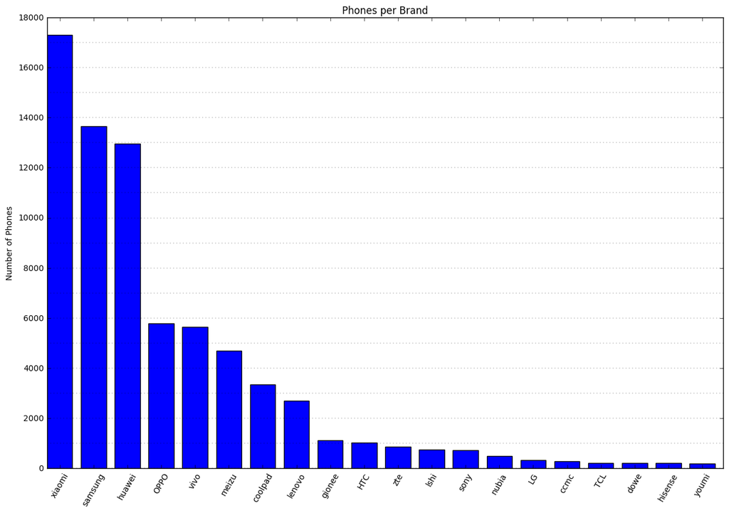

```python
import numpy as np
import matplotlib.pyplot as plt

gender_age_train_brand = pd.read_csv('data/gender_age_brand_train.csv', encoding='utf-8')
most_used = gender_age_train_brand['phone_brand'].value_counts()[:20]

phone_brands = most_used.keys()
brand_counts = list(most_used)

N = len(phone_brands)

ind = np.arange(N)
width = 1.5

fig, ax = plt.subplots()

fig.set_figwidth(15)
fig.set_figheight(10)

for i in np.arange(0, 18000, 1000):
    ax.axhline(y=i,color='k', linewidth=0.3, ls='dotted')

rects1 = ax.bar(ind * 2, brand_counts, width, color='b')

ax.set_ylabel('Number of Phones')
ax.set_title('Phones per Brand')
ax.set_xticks(ind * 2 + width / 2)
ax.set_xticklabels(phone_brands, rotation=60)

plt.show()
```

6.Untersuchen Sie jetzt die Verteilung der Devices über die Marken pro Gender-Age-Group. Gibt es eine Korrelation zwischen Gender-Age-Group und Häufigkeit der Marken? Überlegen sie sich eine Visualisierung mit der eine derartige Korrelation bestätigt oder widerlegt werden kann. Implementieren Sie die Visualisierung und zeigen Sie anhand dieser Visualisierung mögliche Korrelationen zwischen Gender-Age-Group und Markenhäufigkeit.

```python
import numpy as np
from matplotlib import pyplot as plt
from matplotlib import cm as cm

different_groups_fem = pd.read_sql_query('SELECT DISTINCT "group" FROM gender_age_train WHERE gender=="F"', disk_engine).values
different_groups_fem = [group[0] for group in different_groups_fem]
different_groups_fem.sort()

different_groups_mal = pd.read_sql_query('SELECT DISTINCT "group" FROM gender_age_train WHERE gender=="M"', disk_engine).values
different_groups_mal = [group[0] for group in different_groups_mal]
different_groups_mal.sort()

gender_age_brands_fem = {group:
                         {brand: pd.read_sql_query('SELECT COUNT(*) FROM gender_age_brand_train WHERE "group"=="' + group\
                                + '" AND phone_brand=="' + brand + '"', disk_engine).values[0][0] for brand in phone_brands
                         } for group in different_groups_fem}

gender_age_brands_mal = {group:
                         {brand: pd.read_sql_query('SELECT COUNT(*) FROM gender_age_brand_train WHERE "group"=="' + group\
                                + '" AND phone_brand=="' + brand + '"', disk_engine).values[0][0] for brand in phone_brands
                         } for group in different_groups_mal}
```

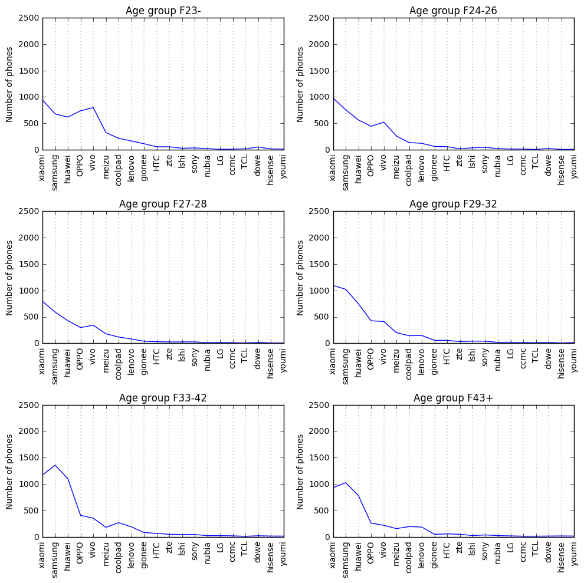

```python
import matplotlib.pyplot as plt
from matplotlib import gridspec

ind = np.arange(N)
width = 1.5

sorted_groups_fem = gender_age_brands_fem.keys()
sorted_groups_fem.sort()

index= 321

fig = plt.figure(figsize=(10, 10))
for group in sorted_groups_fem:
    ax = fig.add_subplot(index)
    index += 1

    ax.set_ylabel('Number of phones')
    ax.set_ylim(0, 2500)
    ax.set_xticks(ind)
    ax.set_title('Age group %s' % group)

    phones = []
    counts = []

    for brand in phone_brands:
        phones.append(brand)
        counts.append(gender_age_brands_fem[group][brand])

    ax.set_xticklabels(phones, rotation=90)
    for i in np.arange(0, 20, 1):
        ax.axvline(x=i,color='k', linewidth=0.3, ls='dotted')
    ax.plot(counts)

plt.tight_layout()
plt.show()
```

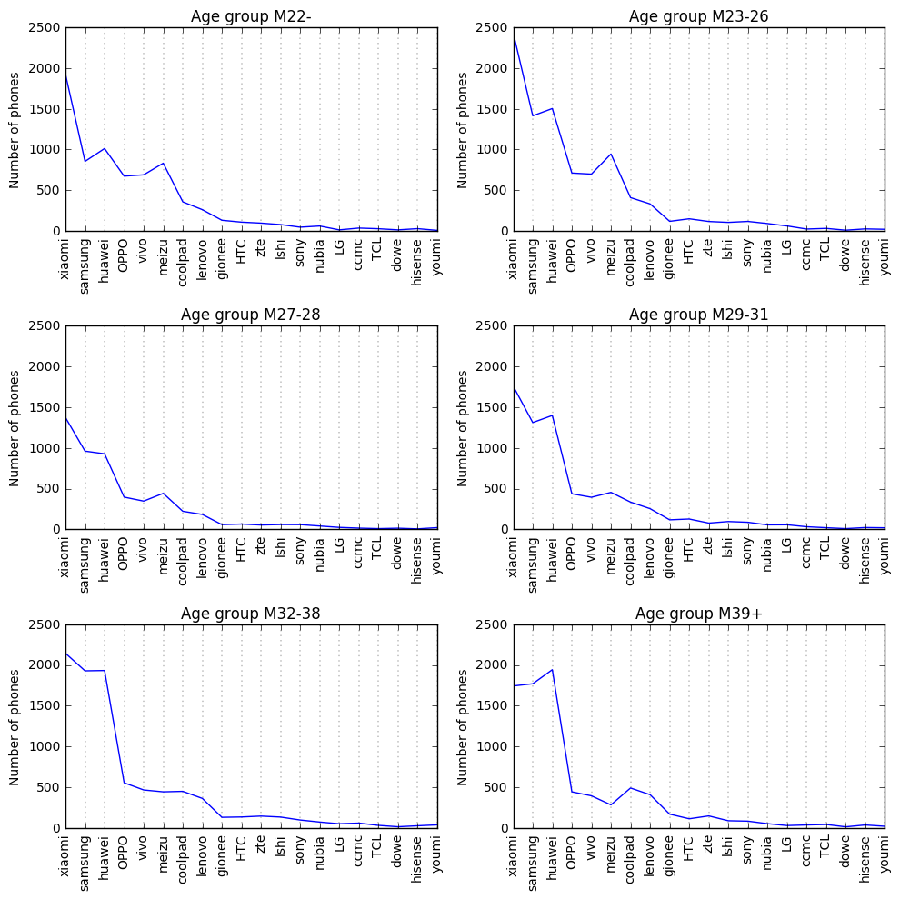

```python
import matplotlib.pyplot as plt
from matplotlib import gridspec

ind = np.arange(N)
width = 1.5

sorted_groups_mal = gender_age_brands_mal.keys()
sorted_groups_mal.sort()

index= 321

fig = plt.figure(figsize=(10, 10))
for group in sorted_groups_mal:
    ax = fig.add_subplot(index)
    index += 1

    ax.set_ylabel('Number of phones')
    ax.set_ylim(0, 2500)
    ax.set_xticks(ind)
    ax.set_title('Age group %s' % group)

    phones = []
    counts = []

    sorted_brands = gender_age_brands_mal[group].keys()
    sorted_brands.sort(key=lambda brand: gender_age_brands_mal[group][brand], reverse=True)

    for brand in phone_brands:
        phones.append(brand)
        counts.append(gender_age_brands_mal[group][brand])

    ax.set_xticklabels(phones, rotation=90)
    for i in np.arange(0, 20, 1):
        ax.axvline(x=i,color='k', linewidth=0.3, ls='dotted')
    ax.plot(counts)

plt.tight_layout()
plt.show()
```

6.Zeigen Sie anhand dieser Visualisierung mögliche Korrelationen zwischen Gender-Age-Group und Markenhäufigkeit.  
**Was als aller erstes im Bezug auf "gender" auffällt, ist, dass deutlich weniger Frauen ein Handy besitzen als Männer. Bei den Frauen kommt nur die Altersgruppe 33-42 knapp an die 1500 Geräte heran. Bei den Männern hingegen liegt nur eine Altergruppe überhaupt unter 1500 Geräten, Altersgruppe 27-28.**

Bei den jüngeren Männern bis 26 ist die Marke "meizu" vergleichsweise beliebt. Die älteren 39+ besitzen dagegen vergleichsweise wenige Geräte der Marke "meizu" Bei den älteren Frauen ab 33 kann man eine vergleichsweise hohe Beliebtheit sehen. Die jüngeren bis 26 haben eine Präferenz für die Marke "vivo".

"Huawei" ist bei den Männern in allen Altersgruppen relativ beliebt, bei en Frauen dagegen weniger.</b>

## Spatio-Temporale Analyse des Verhaltens einzelner User

1. Wählen Sie aus der *events*-Tabelle ein Device, für das mindestens 30 events mit zugewiesenen Geokordinaten vorliegen.
2. Stellen Sie alle Aufenthaltsorte des zu diesem Device gehörenden Users in einer *gmaps-Heatmap* dar. Informationen hierzu finden Sie in der [gmaps-Doku](https://github.com/pbugnion/gmaps). Für den Zugriff auf gmaps benötigen Sie einen Google-API-Key (siehe [gmaps authentication](http://jupyter-gmaps.readthedocs.io/en/latest/authentication.html))

```python
import gmaps
import gmaps.datasets
import pandas as pd
from IPython.display import display
from sqlalchemy import create_engine


disk_engine = create_engine('sqlite:///age_gender_data.db')
gmaps.configure(api_key="AIzaSyClpaNzafIHGEzy8Uqs9p2NUwU-PK1qcSs") # Your Google API key

df = pd.read_sql_query('SELECT * FROM events WHERE device_id = "3915082290673137129"', disk_engine)
# df2 = pd.read_sql_query('SELECT * FROM app_events', disk_engine)

# pd.merge(df, df2, on=['event_id','event_'],how="left")

display(df)

points = zip(df.latitude, df.longitude)

m = gmaps.Map()
m.add_layer(gmaps.Heatmap(data=points))
m
```

|  | index | event_id | device_id | timestamp | longitude | latitude |
| --- | --- | --- | --- | --- | --- | --- |
| 0 | 155 | 155 | 3915082290673137129 | 2016-05-01 00:13:55 | 0.00 | 0.00 |
| 1 | 215 | 215 | 3915082290673137129 | 2016-05-02 00:17:50 | 116.39 | 39.91 |
| 2 | 216 | 216 | 3915082290673137129 | 2016-05-02 00:18:21 | 116.39 | 39.91 |
| 3 | 273 | 273 | 3915082290673137129 | 2016-05-02 00:28:00 | 116.39 | 39.91 |
| 4 | 274 | 274 | 3915082290673137129 | 2016-05-02 00:35:57 | 116.39 | 39.91 |
| 5 | 275 | 275 | 3915082290673137129 | 2016-05-02 00:37:08 | 121.24 | 28.74 |
| 6 | 276 | 276 | 3915082290673137129 | 2016-05-02 00:37:31 | 116.39 | 39.91 |
| 7 | 829 | 829 | 3915082290673137129 | 2016-05-06 00:35:12 | 121.24 | 28.74 |
| 8 | 858 | 858 | 3915082290673137129 | 2016-05-06 00:53:16 | 0.00 | 0.00 |
| 9 | 1090 | 1090 | 3915082290673137129 | 2016-05-01 01:17:10 | 0.00 | 0.00 |
| 10 | 1205 | 1205 | 3915082290673137129 | 2016-05-02 01:23:26 | 121.24 | 28.74 |
| 11 | 1266 | 1266 | 3915082290673137129 | 2016-05-03 01:52:42 | 116.39 | 39.91 |
| 12 | 1309 | 1309 | 3915082290673137129 | 2016-05-03 01:54:26 | 116.39 | 39.91 |
| 13 | 1310 | 1310 | 3915082290673137129 | 2016-05-03 01:59:14 | 116.39 | 39.91 |
| 14 | 1336 | 1336 | 3915082290673137129 | 2016-05-03 01:21:03 | 116.39 | 39.91 |
| 15 | 1337 | 1337 | 3915082290673137129 | 2016-05-03 01:23:32 | 116.39 | 39.91 |
| 16 | 1340 | 1340 | 3915082290673137129 | 2016-05-03 01:28:59 | 116.39 | 39.91 |
| 17 | 1341 | 1341 | 3915082290673137129 | 2016-05-03 01:33:37 | 116.39 | 39.91 |
| 18 | 1342 | 1342 | 3915082290673137129 | 2016-05-03 01:19:41 | 116.39 | 39.91 |
| 19 | 1343 | 1343 | 3915082290673137129 | 2016-05-03 01:32:17 | 116.39 | 39.91 |
| 20 | 1363 | 1363 | 3915082290673137129 | 2016-05-04 01:38:27 | 0.00 | 0.00 |
| 21 | 1365 | 1365 | 3915082290673137129 | 2016-05-04 01:40:55 | 116.39 | 39.91 |
| 22 | 1384 | 1384 | 3915082290673137129 | 2016-05-04 01:04:34 | 116.39 | 39.91 |
| 23 | 1525 | 1525 | 3915082290673137129 | 2016-05-06 01:32:50 | 0.00 | 0.00 |
| 24 | 1605 | 1605 | 3915082290673137129 | 2016-05-07 01:07:29 | 116.39 | 39.91 |
| 25 | 1850 | 1850 | 3915082290673137129 | 2016-05-03 02:17:29 | 116.39 | 39.91 |
| 26 | 1851 | 1851 | 3915082290673137129 | 2016-05-03 02:12:57 | 0.00 | 0.00 |
| 27 | 1995 | 1995 | 3915082290673137129 | 2016-05-05 02:50:48 | 116.39 | 39.91 |
| 28 | 1997 | 1997 | 3915082290673137129 | 2016-05-05 02:56:35 | 0.00 | 0.00 |
| 29 | 2216 | 2216 | 3915082290673137129 | 2016-05-02 02:59:17 | 121.24 | 28.74 |
| ... | ... | ... | ... | ... | ... | ... |
| 14538 | 3243528 | 3243528 | 3915082290673137129 | 2016-05-05 18:05:13 | 0.00 | 0.00 |
| 14539 | 3244206 | 3244206 | 3915082290673137129 | 2016-05-01 19:05:09 | 116.39 | 39.91 |
| 14540 | 3244209 | 3244209 | 3915082290673137129 | 2016-05-01 19:07:52 | 116.39 | 39.91 |
| 14541 | 3244214 | 3244214 | 3915082290673137129 | 2016-05-01 19:12:53 | 116.39 | 39.91 |
| 14542 | 3244355 | 3244355 | 3915082290673137129 | 2016-05-01 19:01:10 | 116.39 | 39.91 |
| 14543 | 3244806 | 3244806 | 3915082290673137129 | 2016-05-03 18:59:49 | 0.00 | 0.00 |
| 14544 | 3246367 | 3246367 | 3915082290673137129 | 2016-05-03 20:05:22 | 0.00 | 0.00 |
| 14545 | 3246614 | 3246614 | 3915082290673137129 | 2016-05-04 20:54:52 | 116.39 | 39.91 |
| 14546 | 3247999 | 3247999 | 3915082290673137129 | 2016-05-02 21:17:42 | 0.00 | 0.00 |
| 14547 | 3248224 | 3248224 | 3915082290673137129 | 2016-05-03 21:11:41 | 116.39 | 39.91 |
| 14548 | 3248502 | 3248502 | 3915082290673137129 | 2016-05-04 21:19:09 | 116.39 | 39.91 |
| 14549 | 3248653 | 3248653 | 3915082290673137129 | 2016-05-04 21:52:43 | 0.00 | 0.00 |
| 14550 | 3248894 | 3248894 | 3915082290673137129 | 2016-05-05 21:20:34 | 0.00 | 0.00 |
| 14551 | 3248898 | 3248898 | 3915082290673137129 | 2016-05-05 21:23:22 | 116.39 | 39.91 |
| 14552 | 3249235 | 3249235 | 3915082290673137129 | 2016-05-06 20:57:45 | 0.00 | 0.00 |
| 14553 | 3249242 | 3249242 | 3915082290673137129 | 2016-05-06 21:31:48 | 0.00 | 0.00 |
| 14554 | 3249658 | 3249658 | 3915082290673137129 | 2016-05-01 22:24:36 | 116.39 | 39.91 |
| 14555 | 3249659 | 3249659 | 3915082290673137129 | 2016-05-01 22:24:53 | 116.39 | 39.91 |
| 14556 | 3249758 | 3249758 | 3915082290673137129 | 2016-05-01 22:23:05 | 116.39 | 39.91 |
| 14557 | 3249760 | 3249760 | 3915082290673137129 | 2016-05-01 22:33:21 | 116.39 | 39.91 |
| 14558 | 3249766 | 3249766 | 3915082290673137129 | 2016-05-01 22:37:23 | 116.39 | 39.91 |
| 14559 | 3249767 | 3249767 | 3915082290673137129 | 2016-05-01 22:51:44 | 121.24 | 28.74 |
| 14560 | 3249769 | 3249769 | 3915082290673137129 | 2016-05-01 22:59:24 | 121.24 | 28.74 |
| 14561 | 3250068 | 3250068 | 3915082290673137129 | 2016-05-03 22:22:00 | 0.00 | 0.00 |
| 14562 | 3250338 | 3250338 | 3915082290673137129 | 2016-05-04 22:05:09 | 116.39 | 39.91 |
| 14563 | 3251001 | 3251001 | 3915082290673137129 | 2016-05-06 22:21:38 | 0.00 | 0.00 |
| 14564 | 3251006 | 3251006 | 3915082290673137129 | 2016-05-06 22:35:31 | 116.39 | 39.91 |
| 14565 | 3251482 | 3251482 | 3915082290673137129 | 2016-05-02 23:52:57 | 0.00 | 0.00 |
| 14566 | 3252224 | 3252224 | 3915082290673137129 | 2016-05-04 23:29:03 | 0.00 | 0.00 |
| 14567 | 3252698 | 3252698 | 3915082290673137129 | 2016-05-06 23:48:12 | 116.39 | 39.91 |

14568 rows × 6 columns

```
Widget Javascript not detected.  It may not be installed properly. Did you enable the widgetsnbextension? If not, then run "jupyter nbextension enable --py --sys-prefix widgetsnbextension"
```

3.Clustern Sie die 2-dimensionalen Geodaten des ausgewählten Users mit dem [DBSCAN-Algorithmus von scikit-learn](http://scikit-learn.org/stable/auto_examples/cluster/plot_dbscan.html). Die Parameter des Algorithmus sind so zu wählen, dass wesentlich unterschiedliche Orte des Users in unterschiedlichen Clustern landen.

```python
import numpy as np
import time
import datetime
from IPython.display import display
from sklearn.cluster import DBSCAN
from sklearn import metrics
from sklearn.datasets.samples_generator import make_blobs
from sklearn.preprocessing import StandardScaler
from operator import itemgetter

db = DBSCAN(eps=0.001, min_samples=10).fit(points)

clusteredPoints = [{
        'point': point,
        'cluster': db.labels_[i],
        'timestamp':  time.mktime(datetime.datetime.strptime(df.timestamp[i],"%Y-%m-%d %H:%M:%S").timetuple()),
        'i': i
    } for (i, point) in enumerate(points)]


sortedClusteredPoints = [x for x in sorted(clusteredPoints, key=itemgetter('timestamp'))]


display(clusteredPoints)
```

[output not shown]

[output cut: 2710 more lines]

[output not shown]

4.Stellen Sie den zeitlichen Verlauf der Events des ausgewählten Users im unten dargestellten Stil visuell dar. Auf der horizontalen Achse ist die Zeit relativ zur Zeit des ersten Events in Sekunden dargestellt. Auf der vertikalen Achse ist die Anzahl der bisherigen Events des Users aufgetragen. Mit jedem Event wird der Wert auf der vertikalen Achse um 1 erhöht. Die Farbe der Marker im Graph gibt den Aufenthaltscluster an. Für jeden in der vorigen Teilaufgabe gefundenen Aufenthaltscluster wird eine unterschiedliche Farbe benutzt (Im Beispiel unten wurden nur 2 Cluster gefunden). Diskutieren Sie das Verhalten des Users anhand des Graphs.

[figure not shown]

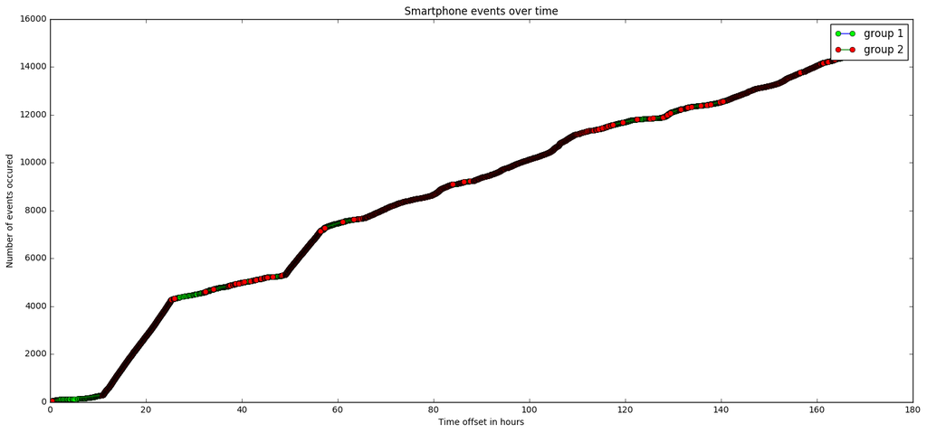

```python
%matplotlib inline
from matplotlib import pyplot as plt

timeOffset = sortedClusteredPoints[0]['timestamp']

group1 = [(i, point) for i, point in enumerate(sortedClusteredPoints) if point['cluster'] == 0]
group2 = [(i, point) for i, point in enumerate(sortedClusteredPoints) if point['cluster'] == 1]

x1 = [ ((point['timestamp'] - timeOffset) / (60 * 60)) for (i, point) in group1 ]
y1 = [ i for (i, point) in group1 ]

x2 = [ ((point['timestamp'] - timeOffset) / (60 * 60)) for (i, point) in group2 ]
y2 = [ i for (i, point) in group2 ]

fig = plt.figure(figsize=(18,8))

plt.title("Smartphone events over time")
plt.ylabel('Number of events occured')
plt.xlabel('Time offset in hours')
plt.plot(x1,y1, markerfacecolor='#00ff00', marker='o', label='group 1')
plt.plot(x2,y2, markerfacecolor='#ff0000', marker='o', label='group 2')
plt.legend()
```

# Feature Extraction

Anmerkung: In den vorigen Aufgaben war das Vorgehen relativ konkret vorgegeben. In den folgenden Aufgaben sind die Vorgaben bewußt knapp gehalten. Ihre Kreativität ist gefragt.

1.Überlegen Sie sich aus welchen Merkmalen, die aus den vorhandenen Daten extrahiert werden können, möglichst gut die Gender-Age-Group vorhergesagt werden kann.

Die Idee ist, die Marken zusammen mit den installierten Apps als Grundlage zu verwenden. Da die Marke selber wie in den zuvor gezeigten Graphen nur sehr wenige Aussage treffen kann, brauchen wir zusätzliche Parameter. Dabei wird davon ausgegeangen, dass Frauen und Männer sich bei der Art der installierten Apps unterscheiden.

2.Extahieren Sie diese Merkmale aus den Daten für möglichst viele (mindestens 20.000) User (devices) aus der Tabelle *gender_age_train*.

train(device_id) -> events(device_id)(event_id) -> app_events(event_id)(app_id) -> app_labels(app_id)(label_id) -> label_categories(label_id)(category)

```python
reduced_devices = pd.read_sql_query('SELECT a.device_id, a."group", b.event_id FROM events b\
                                     JOIN gender_age_train a ON a.device_id == b.device_id\
                                     GROUP BY a.device_id', disk_engine)

print len(reduced_devices.values)
```

```
23309
```

```python
app_events = pd.read_sql_query('SELECT event_id, app_id from app_events', disk_engine)
```

```python
phone_brands = pd.read_sql_query('SELECT device_id, phone_brand FROM phone_brand_device_model', disk_engine)
```

```python
unique_brands = list(phone_brands['phone_brand'].unique())
```

```python
app_labels = pd.read_sql_query('SELECT app_id, label_id from app_labels', disk_engine)
label_categories = pd.read_sql_query('SELECT label_id, category FROM label_categories', disk_engine)
```

```python
joined = reduced_devices\
        .merge(phone_brands, on='device_id')\
        .merge(app_events, on='event_id')\
        .merge(app_labels, on='app_id')\
        .merge(label_categories, on='label_id')
```

```python
reduced_devices = joined['device_id'].unique()
```

```python
list(reduced_devices)
```

[output not shown]

[output cut: 946 more lines]

[output not shown]

```python
unique_groups = list(joined['group'].unique())
unique_groups
```

```
[u'M32-38',
 u'M39+',
 u'M29-31',
 u'F33-42',
 u'M23-26',
 u'M22-',
 u'F43+',
 u'F29-32',
 u'F27-28',
 u'M27-28',
 u'F23-',
 u'F24-26']
```

```python
def get_categories_per_user(device_id):
    categories_per_user = joined.query('device_id==' + str(device_id))['category'].value_counts()
    categories_per_user = { category: amount for category, amount in zip(categories_per_user.keys(), categories_per_user.values) if amount > 5}

    return categories_per_user
```

```python
categories_per_user = get_categories_per_user(-8648070044317879633)

print categories_per_user
```

```
{u'Debit and credit': 14, u'financial': 52, u'Internet Banking': 12, u'P2P': 77, u'And the Church': 49, u'High risk': 25, u'Finance': 19, u'Liquid medium': 28, u'unknown': 39, u'DS_P2P net loan': 9, u'Services 1': 26, u'Industry tag': 101, u'Higher income': 25, u'music': 6, u'Low income': 23, u'1 fr…
```

```python
important_categories = joined['category'].value_counts()
important_categories = [category for category, amount in zip(important_categories.keys(), important_categories.values) if amount > 20]
important_categories.sort()
```

```python
def amount_per_categorie(cat_dict):
    output = []
    for category in important_categories:
        if category in cat_dict:
            output.append(cat_dict[category])
        else:
            output.append(0)

    return output
```

```python
#user_categories = joined.query('device_id==-8648070044317879633 ')['category'].value_counts()

#print dict(user_categories)
```

[output not shown]

```python
#user_vectors = [[(get_one_hot_enc(joined.query('device_id==' +  str(device))['phone_brand'].unique()[0]), amount_per_categorie(categories_per_user)), list(joined.query('device_id==' +  str(device))['group'].unique())[0]] for device in unique_devices[:10]]

#print 'Input: ' + str(user_vectors[0][0]), '\nAge_group: ' + user_vectors[0][1]
```

[output not shown]